# Airbnb New User Bookings Prediction

Carreen de Cardenas

11/28/2017

## About Airbnb and the Project Goals

Airbnb is an online marketplace that creates an outlet for people to list, discover, and book unique living accommodations around the world. The company was founded in 2008 and is based in San Francisco, but Airbnb can now be found in more than 65,000 cities, 191 countries and over 200,000,000 guest have used the service.

The main question we are asking with this dataset and project is “Where will a new guest book their first travel experience?”

Accurately predicting where a new user will book for their first travel experience would allow Airbnb to personalize content, decrease the average time to first book, and better forecast demand.

## Set up

To set up the project, the following libraries were read in and the user and country data was loaded and assigned as “users” and “countries”. The data did not have the data split into train and test so that was also done here:

```r
setwd("~/Documents/4th Year/Statistical Learning/Final Project")

library(readr)
library(dplyr)
```

```r
library(ggplot2)
library(smodels)
library(ggmap)
library(viridis)
library(stringi)
library(xgboost)
users <- read_csv("train_users_2.csv")
countries <- read_csv("countries.csv")
users$train_id <- sample(c('train','test'),nrow(users), replace = TRUE)
```

The countries dataset was merged with the users dataset to show the coordinates of the countries being looked at on the main dataset:

```r
data <- merge(users,countries, by=c('country_destination'))
```

Data about demographics, web session records, and some summary statistics are given for a list of users from the US. There are only 12 potential outcomes for destination looked at in this dataset and are as follows:

‘US’ - United States ‘FR’ - France ‘CA’ - Canada ‘GB’ - Great Britain ‘ES’ - Spain ‘IT’ - Italy ‘PT’ - Portugal ‘NL’ - Netheralands ‘DE’ - Germany ‘AU’ - Austrailia ‘NDF’ - no destination found or no booking ‘other’ - Booking but not in one of the other 180 countries

The 10 potential country destinations can be seen on the map here using a qmplot and the ggmap library:

```
## Using zoom = 2...
```

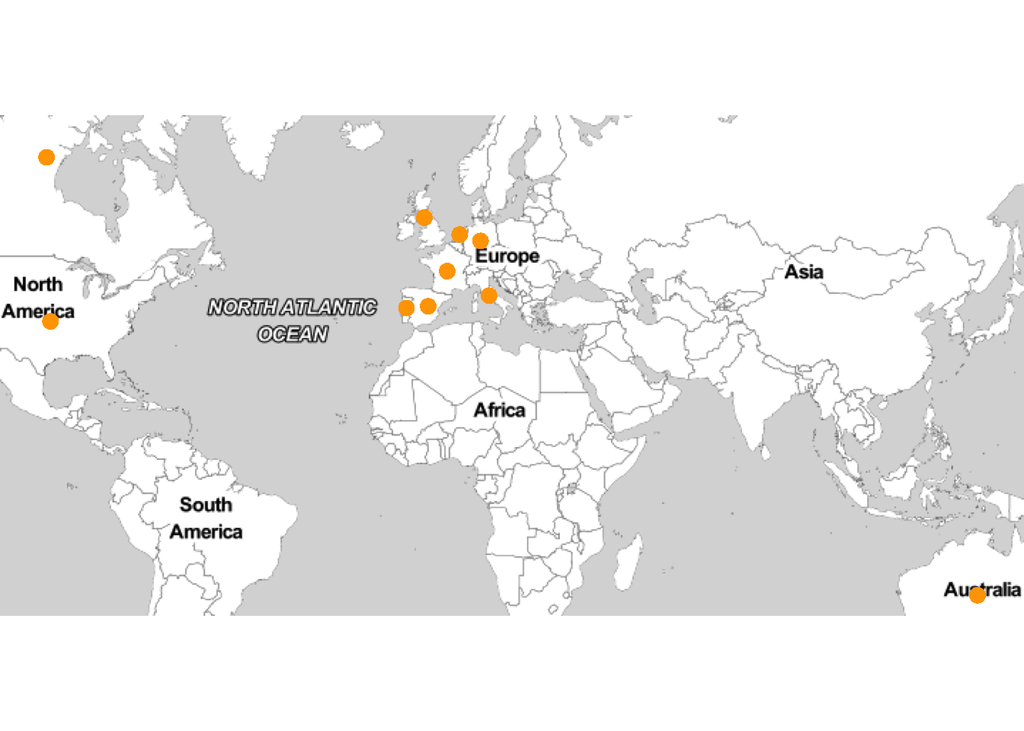

```r
temp <- filter(data, train_id == "train", !(country_destination %in% c("NDF","other")))
qmplot(lng_destination, lat_destination, data = data,
      size = I(3), alpha = I(0.5), color = I("orange"))
```

## Gradient Boosted Trees Model

Some of the categories of data given didn’t seem to relate to the destination where users booked, so those variables were not included in the model. The following categories either hurt or did not benefit the predictiveness of the model for example, and thus left out of the model:

timestamp_first_active: Adding this as a factor lowered the accuracy of the prediction. There were very small differences in the timestamps entered.

date_first_booking: Because the goal is to predict what the first booking will be, using this may help predict on this set but would not be useful when predicting first time users.

language: All users are from the US so almost all of the users had english as a preferred language so that would not effect the prediction.

```r
form <- country_destination ~ date_account_created + gender + age + signup_method + signup_flow + affiliate_channel + affiliate_provider + signup_app + first_device_type + first_browser

X_train <- model.matrix(form, data = users[users$train_id == "train",])
y_train <- model.response(model.frame(form, data = users[users$train_id == "train",]))

X_test <- model.matrix(form, data = users[users$train_id == "test",])
y_test <- model.response(model.frame(form, data = users[users$train_id == "test",]))
```

This dataset did not have all the data for each user which caused some issues when creating the X_train, y_train, X_test, and y_test. I kept getting errors about the logical subcript being too long. R was removing the missing rows when creating the dataset, which threw everyting off. Writing the code as above using the model.frame, model.matrix and model.response mitigated this issue.

The next step was to get turn the country destinations into number values so we could run the model:

```r
cats <- unique(y_train)
y_train <- match(y_train, cats) - 1
y_test <- match(y_test, cats) - 1
```

“multi:softmax” was used as the objective so the above code had to use the -1 to the values from 0-11, because the class is represented by a number and should be from 0 to num_class -1 for the function to be used. We can then use xgboost to do multiclass classification using the softmax objective.

```r
model <- xgboost(data = X_train, label = y_train,
                 max_depth = 3, eta = 0.001, nthread = 20,
                 nrounds = 20, objective = "multi:softmax",
                 verbose = 1, num_class = length(cats))
```

The model was run with more rounds but the values were identical after the first few rounds.

## Results

Using the model above we can see what the prediction rate is for this model:

```r
y_test_pred <- predict(model, newdata = X_test)
mean(y_test == y_test_pred)
```

```
## [1] 0.5304947
```

```r
table(y_test, y_test_pred)
```

```
##       y_test_pred
## y_test     0     1
##     0  17442 10976
##     1   8477 15898
##     2    158   362
##     3    647  1249
##     4    348   658
##     5    303   615
##     6   1333  2486
##     7    312   535
##     8     96   217
##     9    181   258
##     10    71   151
##     11    31    43
```